# R Notebook

# Introduction

Evaluating the impact of financial data is important. This README document seeks to summaries key industry question in financial econometrics. The output and code are described and the order of reason is stated to justify analysis.

# Question 1 - Yield Spreads

This questions seeks to answer weather the South African (SA) current yield spreads in local mid to longer dated bond yields since 2020.

The output suggests that this may have been the case.

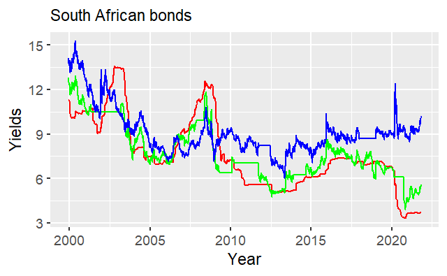

To calculate the current yield spreads in SA:

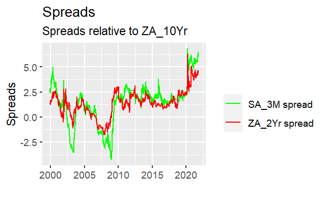

South Africa is part of the BRICS organisation. It is therefore of interest to compare South African bonds on BRICS, Nigeria and the US.

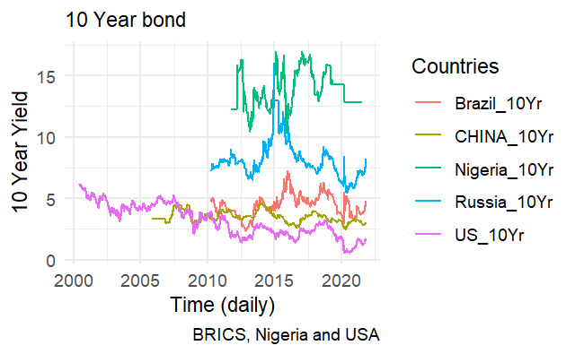

In comparison to the mid dated bond yields since 2020: Internationally the trends indicate that Russia’s 2Yr Bond yield is increasing, as shown the figure below.

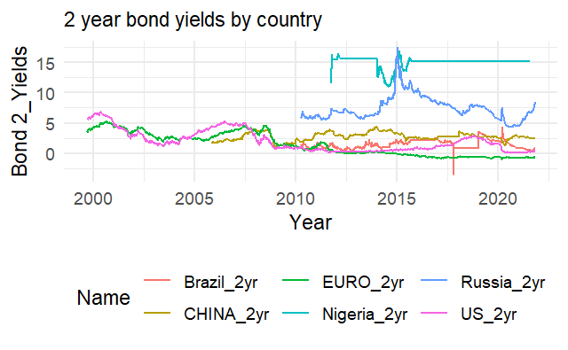

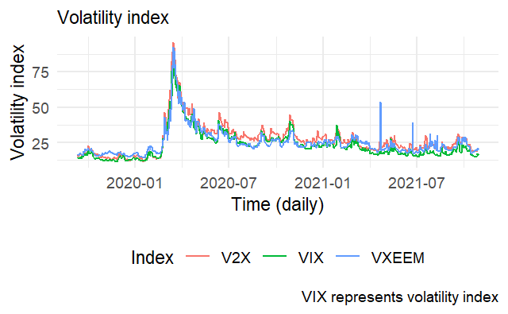

# Question 2 - Portfolio Construction

Aim of the answer was to illustrate the returns and cumulative returns of the J400 and J200 Index. First a missingness analysis is developed, various plots made to illustrate the fluctuations of the sectors. In particular the Resources division. The calculation of a rolling standard deviation is conducted for the indexes with an example of the Naspers shares.

The data is uploaded and a short missingness analysis is conducted as to visualise the missingness of the data. Seen in the figure below. One notes the 1.37% missing data is found in J400.

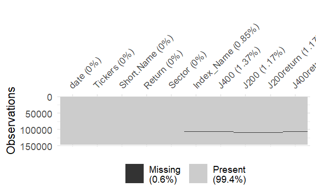

Calculating the return of the portfolio can be calculated as
$$r_{\text{portfilio}}(t) = \sum_{i} w_{i}(t) \times r_{i}(t),$$
where $w_{i}(t)$ is the weight of stock $i$ and $r_{i}(t)$ is the return of stock $i$ for all $i$ stocks.

[figure not shown]

[figure not shown]

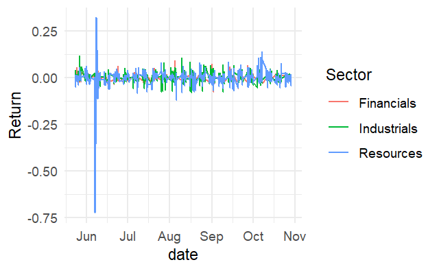

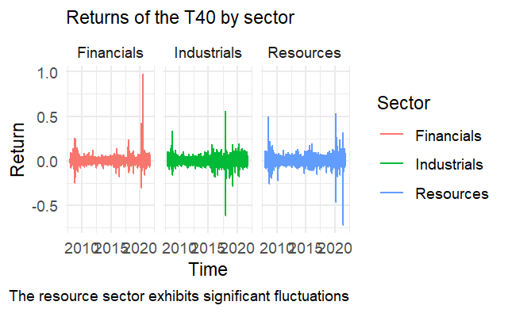

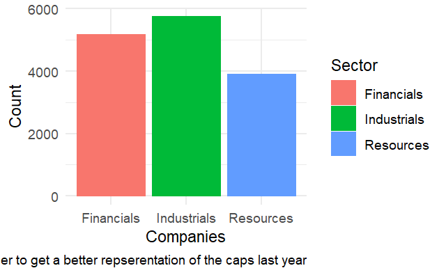

Given the above visualisation of the data - one has to compare the performance of the different Indexes. To do this, the cumulative return needs to calculated.

First we graph the rolling 120 day Standard Deviation. This figure shows when markets are steady, values of low Standard Deviation are expected.Low Standard Deviation values generally precede major price increases. Analysts usually believe that high volatility is associated with significant peaks, whereas low volatility is associated with significant bottoms.The J200 AND J400 returns seem to be moving in the same direction.

[figure not shown]

The figures below describe the cumulative returns by sector. High fluctuations is seen the the resource sector, although it is difficult to see the movement of the other two sectors.

[figure not shown]

[figure not shown]

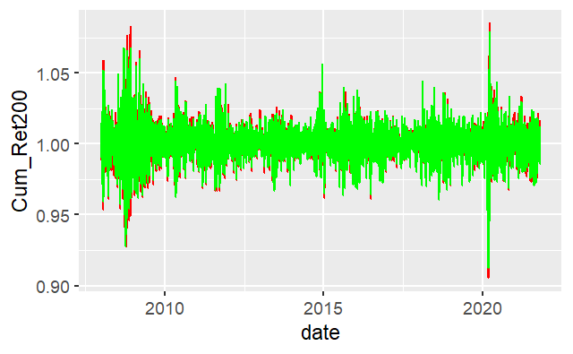

# Question 3